# TP

Alexandre Chen

2024-03-07

# Library

```r
library(readr)
library(caret)
library(MASS)
library(ggplot2)
library(class)
library(ROCR)
library(oddsratio)
library(caTools)
library(xgboost)
```

### 1. Dans cet exercice, on étudie deux bases de données : vin-rouge.csv et vin-blanc.csv. Dans les deux cas, le but est de classifier les vins selon leur qualité qui est représentée par deux modalités : bonne ou mauvaise. Les deux bases de données contiennent les variables suivantes :

- acidité fixe
- acidité volatile
- acide citrique
- sucres résiduels
- chlorures
- dioxide de soufre libre
- dioxide de soufre total
- densité
- pH
- sulphates
- alcool

### Importation de la data

```r
df_b <- read.csv("vin-blanc.csv", header = TRUE ,sep=";")
df_r <- read.csv("vin-rouge.csv", header = TRUE ,sep=";")
```

#### 1. Coder la variable qualité en variable binaire avec comme modalités : “mauvaise qualité” si le score est inférieur ou égal à 5 et de “bonne qualité” si le score est supérieur ou égal à 6. Donner la taille de la base de données et le pourcentage de chacune des modalités.

```r
df_quality_b <- df_quality_b[,-12]
df_quality_r <- df_quality_r[,-12]
```

> Vin
- VIN ROUGE

```r
head(df_quality_r)
```

```
##   acidite_fixe acidite_volatile acide_citrique sucres_residuels chlorures
## 1          7.4             0.70           0.00              1.9     0.076
## 2          7.8             0.88           0.00              2.6     0.098
## 3          7.8             0.76           0.04              2.3     0.092
## 4         11.2             0.28           0.56              1.9     0.075
## 5          7.4             0.70           0.00              1.9     0.076
## 6          7.4             0.66           0.00              1.8     0.075
##   dioxide_de_soufre_libre dioxyde_de_soufre_total densite   pH sulfites alcool
## 1                      11                      34  0.9978 3.51     0.56    9.4
## 2                      25                      67  0.9968 3.20     0.68    9.8
## 3                      15                      54  0.9970 3.26     0.65    9.8
## 4                      17                      60  0.9980 3.16     0.58    9.8
## 5                      11                      34  0.9978 3.51     0.56    9.4
## 6                      13                      40  0.9978 3.51     0.56    9.4
##       mark_quality
## 1 mauvaise qualité
## 2 mauvaise qualité
## 3 mauvaise qualité
## 4    bonne qualité
## 5 mauvaise qualité
## 6 mauvaise qualité
```

```
## Taille de la base de données rouge: 1599
```

```
## Pourcentage de mauvaise qualité dans la base de données du vin rouge est de  46.52908 %
```

```
## Pourcentage de bonne qualité dans la base de données du vin rouge est de 53.47092 %
```

- VIN BLANC

```r
head(df_quality_b)
```

```
##   fixed.acidity volatile.acidity citric.acid residual.sugar chlorides
## 1           7.0             0.27        0.36           20.7     0.045
## 2           6.3             0.30        0.34            1.6     0.049
## 3           8.1             0.28        0.40            6.9     0.050
## 4           7.2             0.23        0.32            8.5     0.058
## 5           7.2             0.23        0.32            8.5     0.058
## 6           8.1             0.28        0.40            6.9     0.050
##   free.sulfur.dioxide total.sulfur.dioxide density   pH sulphates alcohol
## 1                  45                  170  1.0010 3.00      0.45     8.8
## 2                  14                  132  0.9940 3.30      0.49     9.5
## 3                  30                   97  0.9951 3.26      0.44    10.1
## 4                  47                  186  0.9956 3.19      0.40     9.9
## 5                  47                  186  0.9956 3.19      0.40     9.9
## 6                  30                   97  0.9951 3.26      0.44    10.1
##    mark_quality
## 1 bonne qualité
## 2 bonne qualité
## 3 bonne qualité
## 4 bonne qualité
## 5 bonne qualité
## 6 bonne qualité
```

```
## Taille de la base de données blanc: 4898
```

```
## Pourcentage de mauvaise qualité dans la base de données du vin blanc est de  33.48305 %
```

```
## Pourcentage de bonne qualité dans la base de données du vin blanc est de  66.51695 %
```

#### 2. Construire une base de données d’apprentissage et de test, la première contenant 80% des données et la deuxième les 20% restants

> Vin
- VIN ROUGE

```r
index_r <- createDataPartition(df_quality_r$mark_quality, p = 0.8, list = FALSE)
df_app_r <- df_quality_r[index_r, ]
df_test_r <- df_quality_r[-index_r, ]
```

```
## Pourcentage de bonne qualité dans la base de données d'apprentissage du vin rouge est de  53.4375 %
```

```
## Pourcentage de bonne qualité dans la base de données de test du vin rouge est de  53.60502 %
```

- VIN BLANC

```r
index_b <- createDataPartition(df_quality_b$mark_quality, p = 0.8, list = FALSE)
df_app_b <- df_quality_b[index_b, ]
df_test_b <- df_quality_b[-index_b, ]
```

```
## Pourcentage de bonne qualité dans la base de données d'apprentissage du vin blanc est de  66.52207 %
```

```
## Pourcentage de bonne qualité dans la base de données de test du vin blanc est de  66.49642 %
```

on obtient un taux semblable à celui de la base de donnée de départ.

#### 3. Implémenter un modèle de mélange Gaussien homoscédastique (lda) sur la base d’apprentissage et calculer le taux de mauvaise classification sur la base de données test.

```r
df_quality_b$mark_quality <- as.factor(df_quality_b$mark_quality)
df_quality_r$mark_quality <- as.factor(df_quality_r$mark_quality)
```

> Vin
- VIN ROUGE

```r
set.seed(2408)
modele_lda_r <- lda(mark_quality ~ ., data = df_app_r)
lda_pred_r <- predict(modele_lda_r, newdata = df_test_r)

lda_error_rr <- mean(lda_pred_r$class != df_test_r$mark_quality)
```

```
## Taux de mauvaise classification avec LDA pour la base de test rouge est de 0.2664577
```

- VIN BLANC

```r
set.seed(2408)
modele_lda_b <- lda(mark_quality ~ ., data = df_app_b)
lda_pred_b <- predict(modele_lda_b, newdata = df_test_b)
lda_error_rb <- mean(lda_pred_b$class != df_test_b$mark_quality)
```

```
## Taux de mauvaise classification avec LDA pour la base de test blanc est de 0.258427
```

#### 4. Même question avec un modèle de mélange Gaussien hétéroscédastique (qda). Quelle est la meilleure méthode de classification ?

> Vin
- VIN ROUGE

```r
set.seed(2408)
modele_qda_r <- qda(mark_quality ~ ., data = df_app_r)
qda_pred_r <- predict(modele_qda_r, newdata = df_test_r)
lda_error_rr <- mean(qda_pred_r$class != df_test_r$mark_quality)
```

```
## Taux de mauvaise classification avec QDA pour la base de test rouge est de 0.2978056
```

- VIN BLANC

```r
set.seed(2408)
modele_qda_b <- qda(mark_quality ~ ., data = df_app_b)
qda_pred_b <- predict(modele_qda_b, newdata = df_test_b)

lda_error_rb <- mean(qda_pred_b$class != df_test_b$mark_quality)
```

```
## Taux de mauvaise classification avec QDA pour la base de test blanc est de 0.2543412
```

#### 5. La méthode lda peut également être vue comme une méthode de réduction de dimension. Afficher la projection des individus sur l’axe maximisant la distance entre les moyennes projetées, normalisée par la variance intra-classe des projections. Commenter.

- VIN ROUGE

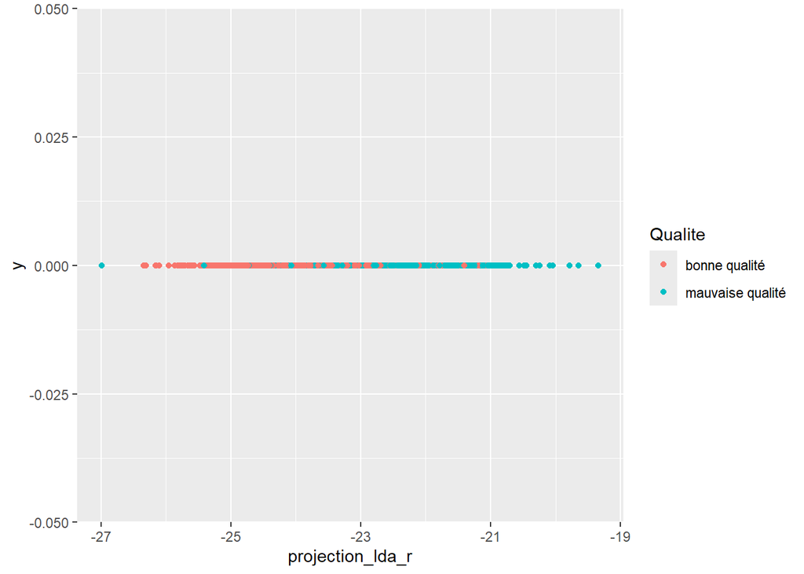

- VIN BLANC

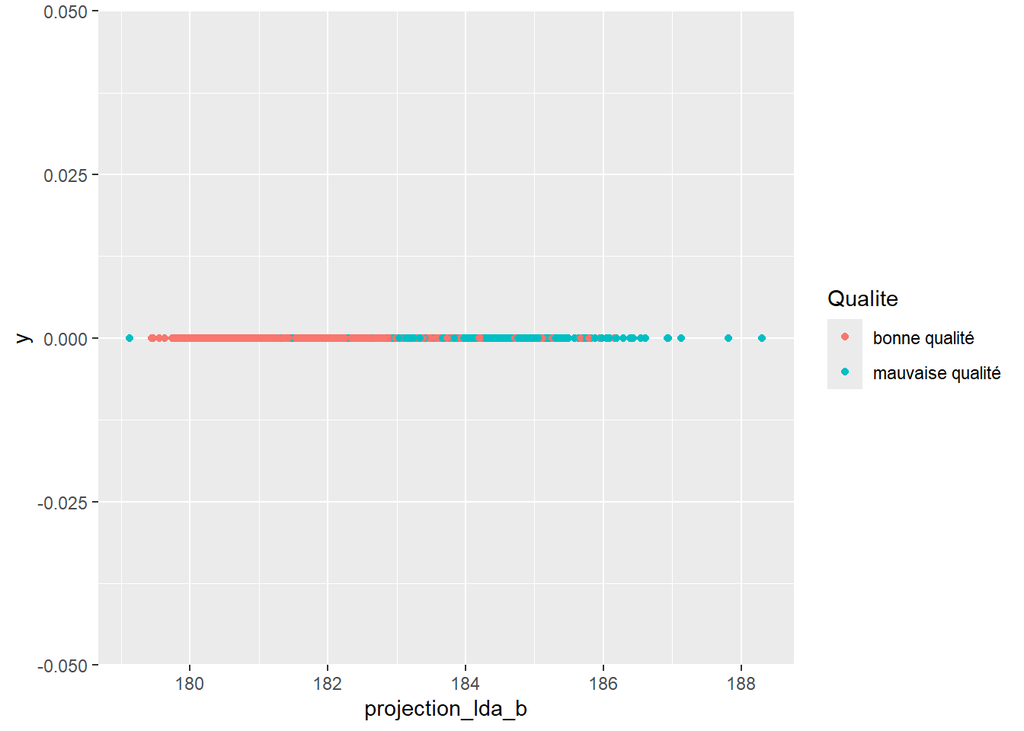

On peut voir que les deux graphiques sont similaires, cependant on note une légère différence entre le vin blanc et rouge.

#### 6. Implémenter le modèle des k plus proches voisins. On se donnera une grille de valeurs de k et vous afficherez sur un graphique le taux de mauvaise classification en fonction de k

```
##                   classifier_knn
##                    bonne qualité mauvaise qualité
##   bonne qualité              136               35
##   mauvaise qualité            37              111
```

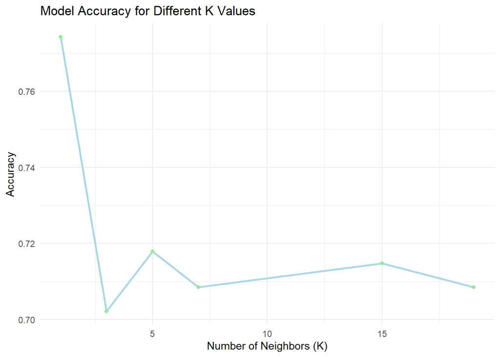

Grâce à ce graphique on peut voir la précision de la prédiction avec le nombre de K on choisi, ici il est mieux de prendre un voisin avec k = 1

#### 7. Implémenter le modèle de régression logistique sur la base de données complète. Commenter les oddsratios et les tests correspondants. Quelles variables semblent influer sur la qualité du vin ?

```
##
## Call:
## glm(formula = mark_quality ~ ., family = "binomial", data = df_app_r)
##
## Coefficients:
##                           Estimate Std. Error z value Pr(>|z|)
## (Intercept)             -17.297841  90.009781  -0.192  0.84760
## acidite_fixe              0.095857   0.109151   0.878  0.37983
## acidite_volatile         -3.166079   0.542410  -5.837 5.31e-09 ***
## acide_citrique           -1.429699   0.633885  -2.255  0.02410 *
## sucres_residuels         -0.003051   0.061880  -0.049  0.96068
## chlorures                -4.253019   1.767881  -2.406  0.01614 *
## dioxide_de_soufre_libre   0.030843   0.009743   3.166  0.00155 **
## dioxyde_de_soufre_total  -0.022357   0.003649  -6.127 8.93e-10 ***
## densite                  10.062458  91.832581   0.110  0.91275
## pH                       -0.460311   0.813468  -0.566  0.57149
## sulfites                  3.058661   0.517963   5.905 3.52e-09 ***
## alcool                    0.880589   0.117609   7.487 7.02e-14 ***
## ---
## Signif. codes:  0 '***' 0.001 '**' 0.01 '*' 0.05 '.' 0.1 ' ' 1
##
## (Dispersion parameter for binomial family taken to be 1)
##
##     Null deviance: 1768.4  on 1279  degrees of freedom
## Residual deviance: 1311.7  on 1268  degrees of freedom
## AIC: 1335.7
##
## Number of Fisher Scoring iterations: 4
```

Les variables qui ont une forte influance sur la qualité du vin sont majoritairement : l’alcool, dioxyde_de_soufre_total, sulfites et acidite_volatile

#### 8. Implémenter le modèle de régression logistique sur la base d’apprentissage et calculer le taux de mauvaise classification sur la base de données test.

```r
logistic_model
```

```
##
## Call:  glm(formula = mark_quality ~ ., family = "binomial", data = df_app_r)
##
## Coefficients:
##             (Intercept)             acidite_fixe         acidite_volatile
##              -17.297841                 0.095857                -3.166079
##          acide_citrique         sucres_residuels                chlorures
##               -1.429699                -0.003051                -4.253019
## dioxide_de_soufre_libre  dioxyde_de_soufre_total                  densite
##                0.030843                -0.022357                10.062458
##                      pH                 sulfites                   alcool
##               -0.460311                 3.058661                 0.880589
##
## Degrees of Freedom: 1279 Total (i.e. Null);  1268 Residual
## Null Deviance:       1768
## Residual Deviance: 1312  AIC: 1336
```

```r
predict_reg <- ifelse(predict_reg >0.5, 1, 0)

# Evaluating model accuracy
# using confusion matrix
table(df_test_r$mark_quality, predict_reg)
```

```
##    predict_reg
##       0   1
##   0 109  39
##   1  47 124
```

```r
missing_classerr <- mean(predict_reg != df_test_r$mark_quality)
print(paste('Accuracy =', 1 - missing_classerr))
```

```
## [1] "Accuracy = 0.730407523510972"
```

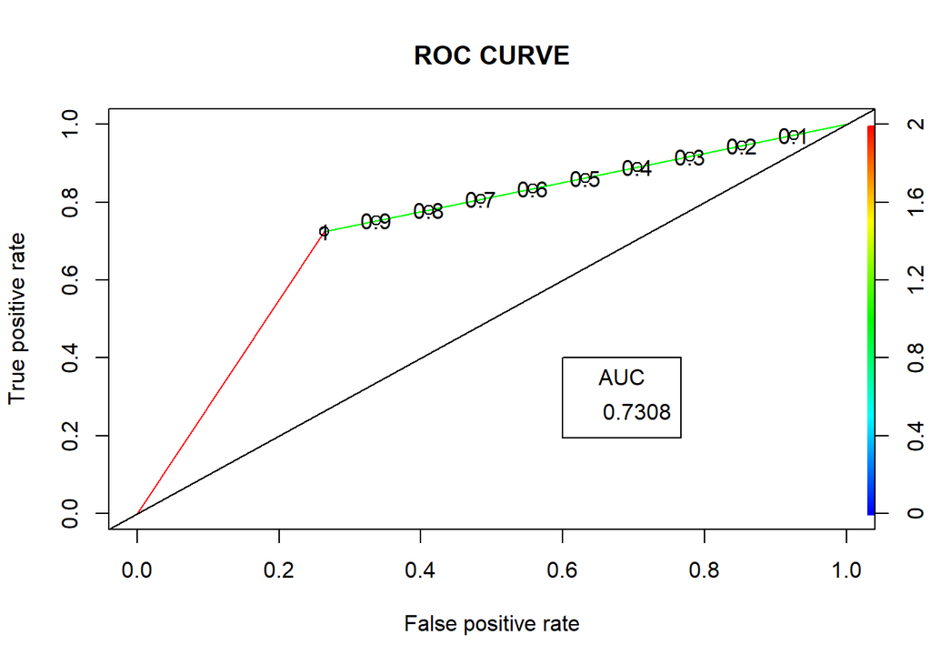

```
## Avec la régression logistique on obtient une performance de 0.7308 se qui signifie que le modèle possède de bonne performances car supérieur à 0.5
```

```r
# ROC-AUC Curve
ROCPred <- prediction(predict_reg, df_test_r$mark_quality)
ROCPer <- performance(ROCPred, measure = "tpr",
                      x.measure = "fpr")

auc <- performance(ROCPred, measure = "auc")
auc <- auc@y.values[[1]]

# Plotting curve
plot(ROCPer, colorize = TRUE,
     print.cutoffs.at = seq(0.1, by = 0.1),
     main = "ROC CURVE")
abline(a = 0, b = 1)

auc <- round(auc, 4)
legend(.6, .4, auc, title = "AUC", cex = 1)
```

```r
predictions <- predict(logistic_model, newdata = df_test_r, type = "response")
predicted_classes <- ifelse(predictions > 0.5, 1, 0)

misclassification_rate <- mean(predicted_classes != df_test_r[,12])
```

[output not shown]